# regression problem

Adreanna Morales

2/16/2020

# Introduction:

Data are from the website http://fueleconomy.gov This is a problem in modeling/prediction. The idea is this: Fuel efficiency from 2010 and 2011 passenger cars and light trucks is provied. Using data from 2010, find the best model to predict fuel effiency; fit the model using data from 2010, and evaluate model performance using 2011 data.

Questions:  
1. Is there evidence of an improvement in fuel efficiency from 2010 to 2011?  
2. What variables are most significant predictors of fuel efficienty?  
3. Suggest ways in which fuel efficienty could be improved in future years.

data set: fuel economy from US Gov’t website

```r
data(FuelEconomy)
library(lattice)
```

### Plot shown in the text:

load the data FE is fuel economy

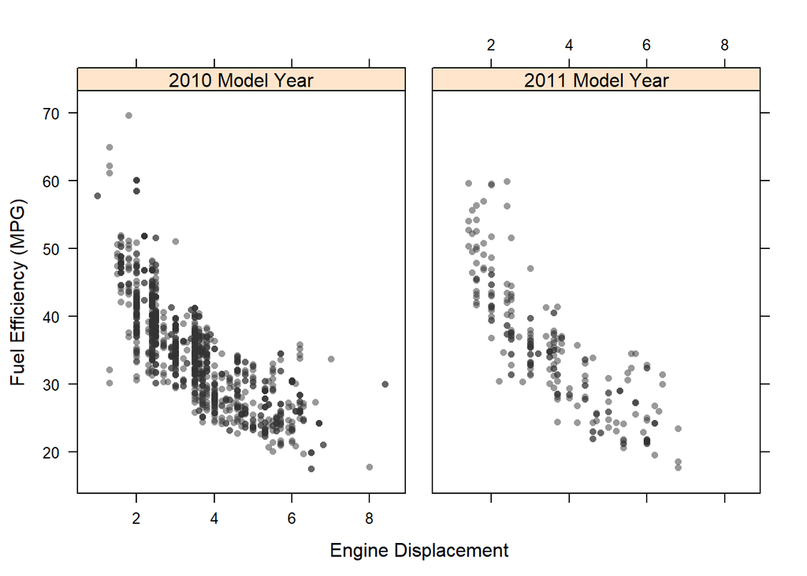

```r
cars2010 <- cars2010[order(cars2010$EngDispl),]
cars2011 <- cars2011[order(cars2011$EngDispl),]
cars2010a <- cars2010
cars2010a$Year <- "2010 Model Year"
cars2011a <- cars2011
cars2011a$Year <- "2011 Model Year"
plotData <- rbind(cars2010a, cars2011a)
plotTheme <- bookTheme(FALSE)
plotTheme$plot.symbol$col <- rgb(.2, .2, .2, .5)
plotTheme$plot.symbol$cex <- 0.7
trellis.par.set(plotTheme)

xyplot(FE ~ EngDispl|Year, plotData,
xlab = "Engine Displacement",
ylab = "Fuel Efficiency (MPG)",
between = list(x = 1.2))
```

##d differences in mean fuel efficiency 2010 to 2011

$H_O$: no difference between FE in 2010 and 2011 $H_A$: there is a difference in FE for years 2010 and 2011

We’ll use t test for this inference

```r
t.test(cars2010a$FE, cars2011a$FE)
```

```
##
##  Welch Two Sample t-test
##
## data:  cars2010a$FE and cars2011a$FE
## t = -0.038381, df = 319.38, p-value = 0.9694
## alternative hypothesis: true difference in means is not equal to 0
## 95 percent confidence interval:
##  -1.263399  1.215049
## sample estimates:
## mean of x mean of y
##  34.70649  34.73066
```

Question #1 No evidence of any improvement/differemce in mean FE between 2010 and 2011

### variables in the data set: to

```r
names(cars2010a)
```

```
##  [1] "EngDispl"            "NumCyl"              "Transmission"
##  [4] "FE"                  "AirAspirationMethod" "NumGears"
##  [7] "TransLockup"         "TransCreeperGear"    "DriveDesc"
## [10] "IntakeValvePerCyl"   "ExhaustValvesPerCyl" "CarlineClassDesc"
## [13] "VarValveTiming"      "VarValveLift"        "Year"
```

```r
testTranny = filter(cars2010a, Transmission %in% c('AV', 'M5','AM6'))
trannyModel = glm(FE ~ Transmission, data = testTranny)
summary(trannyModel)
```

```
##
## Call:
## glm(formula = FE ~ Transmission, data = testTranny)
##
## Deviance Residuals:
##     Min       1Q   Median       3Q      Max
## -15.440   -5.140   -1.265    4.160   29.415
##
## Coefficients:
##                Estimate Std. Error t value Pr(>|t|)
## (Intercept)      27.371      2.163  12.655  < 2e-16 ***
## TransmissionAV   12.854      2.369   5.425 2.05e-07 ***
## TransmissionM5   13.269      2.278   5.825 2.93e-08 ***
## ---
## Signif. codes:  0 '***' 0.001 '**' 0.01 '*' 0.05 '.' 0.1 ' ' 1
##
## (Dispersion parameter for gaussian family taken to be 51.46303)
##
##     Null deviance: 10215.5  on 166  degrees of freedom
## Residual deviance:  8439.9  on 164  degrees of freedom
## AIC: 1137
##
## Number of Fisher Scoring iterations: 2
```

```r
print(mean(testTranny$FE))
```

```
## [1] 39.62966
```

### Anova on Transmission Only

```r
model9 = glm(FE ~ Transmission,data = cars2010a)

summary (model9)
```

```
##
## Call:
## glm(formula = FE ~ Transmission, data = cars2010a)
##
## Deviance Residuals:
##      Min        1Q    Median        3Q       Max
## -23.0279   -4.7142   -0.3706    4.0121   29.4149
##
## Coefficients:
##                  Estimate Std. Error t value Pr(>|t|)
## (Intercept)       40.5279     2.7990  14.479  < 2e-16 ***
## TransmissionA4    -6.2463     2.8572  -2.186 0.029012 *
## TransmissionA5    -9.5440     2.8718  -3.323 0.000919 ***
## TransmissionA6    -8.7094     2.8649  -3.040 0.002422 **
## TransmissionA7    -8.1310     2.9379  -2.768 0.005743 **
## TransmissionAM6  -13.1565     3.4797  -3.781 0.000165 ***
## TransmissionAM7  -18.4948     4.1516  -4.455 9.26e-06 ***
## TransmissionAV    -0.3024     2.9478  -0.103 0.918312
## TransmissionAVS6  -1.5586     3.3839  -0.461 0.645173
## TransmissionM5     0.1123     2.8810   0.039 0.968903
## TransmissionM6    -4.3577     2.8489  -1.530 0.126404
## TransmissionS4    -5.9990     3.3839  -1.773 0.076539 .
## TransmissionS5    -4.6948     2.9688  -1.581 0.114085
## TransmissionS6    -6.0227     2.8382  -2.122 0.034061 *
## TransmissionS7    -9.8227     3.1577  -3.111 0.001915 **
## TransmissionS8    -8.4734     3.4797  -2.435 0.015046 *
## ---
## Signif. codes:  0 '***' 0.001 '**' 0.01 '*' 0.05 '.' 0.1 ' ' 1
##
## (Dispersion parameter for gaussian family taken to be 47.0077)
##
##     Null deviance: 62180  on 1106  degrees of freedom
## Residual deviance: 51285  on 1091  degrees of freedom
## AIC: 7421.7
##
## Number of Fisher Scoring iterations: 2
```

```r
anova(model9)
```

```
## Analysis of Deviance Table
##
## Model: gaussian, link: identity
##
## Response: FE
##
## Terms added sequentially (first to last)
##
##
##              Df Deviance Resid. Df Resid. Dev
## NULL                          1106      62180
## Transmission 15    10894      1091      51285
```

Transmission AV and M5 have the least negative impact to fuel efficiency

```r
levels(cars2010a$ExhaustValvesPerCyl)
```

[output not shown]

```r
trannyvalveModel = glm(FE ~ Transmission + ExhaustValvesPerCyl, data = testTranny)
summary(trannyvalveModel)
```

```
##
## Call:
## glm(formula = FE ~ Transmission + ExhaustValvesPerCyl, data = testTranny)
##
## Deviance Residuals:
##     Min       1Q   Median       3Q      Max
## -15.766   -4.514   -1.395    3.804   30.039
##
## Coefficients:
##                     Estimate Std. Error t value Pr(>|t|)
## (Intercept)           14.211      4.313   3.295 0.001207 **
## TransmissionAV        14.170      2.323   6.099 7.49e-09 ***
## TransmissionM5        13.595      2.206   6.163 5.40e-09 ***
## ExhaustValvesPerCyl    6.580      1.885   3.490 0.000621 ***
## ---
## Signif. codes:  0 '***' 0.001 '**' 0.01 '*' 0.05 '.' 0.1 ' ' 1
##
## (Dispersion parameter for gaussian family taken to be 48.17858)
##
##     Null deviance: 10215.5  on 166  degrees of freedom
## Residual deviance:  7853.1  on 163  degrees of freedom
## AIC: 1127
##
## Number of Fisher Scoring iterations: 2
```

## ANOVA

```r
model8 = glm(FE ~ EngDispl+NumCyl+AirAspirationMethod+VarValveTiming+NumGears+IntakeValvePerCyl+VarValveLift+TransLockup +ExhaustValvesPerCyl+TransCreeperGear,data = cars2010a)

summary (model8)
```

```
##
## Call:
## glm(formula = FE ~ EngDispl + NumCyl + AirAspirationMethod +
##     VarValveTiming + NumGears + IntakeValvePerCyl + VarValveLift +
##     TransLockup + ExhaustValvesPerCyl + TransCreeperGear, data = cars2010a)
##
## Deviance Residuals:
##      Min        1Q    Median        3Q       Max
## -17.5069   -2.8409   -0.3192    2.6053   25.5663
##
## Coefficients:
##                                 Estimate Std. Error t value Pr(>|t|)
## (Intercept)                      54.4756     1.0975  49.637  < 2e-16 ***
## EngDispl                         -4.0131     0.2897 -13.855  < 2e-16 ***
## NumCyl                           -0.4148     0.1876  -2.211   0.0272 *
## AirAspirationMethodSupercharged  -0.8709     1.0844  -0.803   0.4221
## AirAspirationMethodTurbocharged  -0.9074     0.4033  -2.250   0.0246 *
## VarValveTiming                    1.6526     0.3793   4.357 1.44e-05 ***
## NumGears                         -0.1203     0.1086  -1.108   0.2682
## IntakeValvePerCyl                -0.1828     0.9955  -0.184   0.8543
## VarValveLift                      0.5376     0.3732   1.441   0.1500
## TransLockup                      -1.5010     0.3007  -4.992 6.94e-07 ***
## ExhaustValvesPerCyl              -1.3426     0.9672  -1.388   0.1654
## TransCreeperGear                 -1.0723     0.6708  -1.598   0.1102
## ---
## Signif. codes:  0 '***' 0.001 '**' 0.01 '*' 0.05 '.' 0.1 ' ' 1
##
## (Dispersion parameter for gaussian family taken to be 20.08847)
##
##     Null deviance: 62180  on 1106  degrees of freedom
## Residual deviance: 21997  on 1095  degrees of freedom
## AIC: 6476.6
##
## Number of Fisher Scoring iterations: 2
```

```r
anova(model8)
```

```
## Analysis of Deviance Table
##
## Model: gaussian, link: identity
##
## Response: FE
##
## Terms added sequentially (first to last)
##
##
##                     Df Deviance Resid. Df Resid. Dev
## NULL                                 1106      62180
## EngDispl             1    38551      1105      23629
## NumCyl               1      247      1104      23382
## AirAspirationMethod  2      104      1102      23278
## VarValveTiming       1      415      1101      22863
## NumGears             1       61      1100      22802
## IntakeValvePerCyl    1      145      1099      22657
## VarValveLift         1       75      1098      22582
## TransLockup          1      512      1097      22070
## ExhaustValvesPerCyl  1       22      1096      22048
## TransCreeperGear     1       51      1095      21997
```

### 2 Answer

```r
model6 = glm(FE ~ EngDispl+NumCyl+AirAspirationMethod+TransCreeperGear+DriveDesc,data =cars2010a)

summary(model6)
```

```
##
## Call:
## glm(formula = FE ~ EngDispl + NumCyl + AirAspirationMethod +
##     TransCreeperGear + DriveDesc, data = cars2010a)
##
## Deviance Residuals:
##      Min        1Q    Median        3Q       Max
## -12.9597   -2.6429   -0.1713    2.2719   25.6844
##
## Coefficients:
##                                  Estimate Std. Error t value Pr(>|t|)
## (Intercept)                     45.985920   0.574202  80.087  < 2e-16 ***
## EngDispl                        -2.904854   0.243916 -11.909  < 2e-16 ***
## NumCyl                          -0.578996   0.158728  -3.648 0.000277 ***
## AirAspirationMethodSupercharged  0.007552   0.965631   0.008 0.993761
## AirAspirationMethodTurbocharged -0.026070   0.362278  -0.072 0.942645
## TransCreeperGear                -1.298510   0.568215  -2.285 0.022489 *
## DriveDescFourWheelDrive         -0.787525   0.451223  -1.745 0.081210 .
## DriveDescParttimeFourWheelDrive -2.308553   1.262323  -1.829 0.067699 .
## DriveDescTwoWheelDriveFront      5.514770   0.381530  14.454  < 2e-16 ***
## DriveDescTwoWheelDriveRear       2.108129   0.369993   5.698 1.56e-08 ***
## ---
## Signif. codes:  0 '***' 0.001 '**' 0.01 '*' 0.05 '.' 0.1 ' ' 1
##
## (Dispersion parameter for gaussian family taken to be 16.24396)
##
##     Null deviance: 62180  on 1106  degrees of freedom
## Residual deviance: 17820  on 1097  degrees of freedom
## AIC: 6239.5
##
## Number of Fisher Scoring iterations: 2
```

```r
anova(model6)
```

```
## Analysis of Deviance Table
##
## Model: gaussian, link: identity
##
## Response: FE
##
## Terms added sequentially (first to last)
##
##
##                     Df Deviance Resid. Df Resid. Dev
## NULL                                 1106      62180
## EngDispl             1    38551      1105      23629
## NumCyl               1      247      1104      23382
## AirAspirationMethod  2      104      1102      23278
## TransCreeperGear     1      160      1101      23118
## DriveDesc            4     5298      1097      17820
```

Its appears that TransCreeperGear is a drag leave it out; drive desc fronyt 2 wheel

```r
pruned2010a = filter(cars2010a, TransCreeperGear==0 & DriveDesc== 'TwoWheelDriveFront' & EngDispl < 3)


model2 = glm(FE ~ EngDispl+NumCyl, data=pruned2010a)

summary(model2)
```

```
##
## Call:
## glm(formula = FE ~ EngDispl + NumCyl, data = pruned2010a)
##
## Deviance Residuals:
##      Min        1Q    Median        3Q       Max
## -11.0787   -2.8462   -0.3808    1.9854   22.7568
##
## Coefficients:
##             Estimate Std. Error t value Pr(>|t|)
## (Intercept)  67.1308     3.1755  21.140   <2e-16 ***
## EngDispl     -8.5243     0.9345  -9.121   <2e-16 ***
## NumCyl       -1.2259     0.8009  -1.531    0.127
## ---
## Signif. codes:  0 '***' 0.001 '**' 0.01 '*' 0.05 '.' 0.1 ' ' 1
##
## (Dispersion parameter for gaussian family taken to be 23.07444)
##
##     Null deviance: 8873.6  on 275  degrees of freedom
## Residual deviance: 6299.3  on 273  degrees of freedom
## AIC: 1654.5
##
## Number of Fisher Scoring iterations: 2
```

```r
anova(model2)
```

```
## Analysis of Deviance Table
##
## Model: gaussian, link: identity
##
## Response: FE
##
## Terms added sequentially (first to last)
##
##
##          Df Deviance Resid. Df Resid. Dev
## NULL                       275     8873.6
## EngDispl  1  2520.22       274     6353.4
## NumCyl    1    54.06       273     6299.3
```

make a prediction for 2011

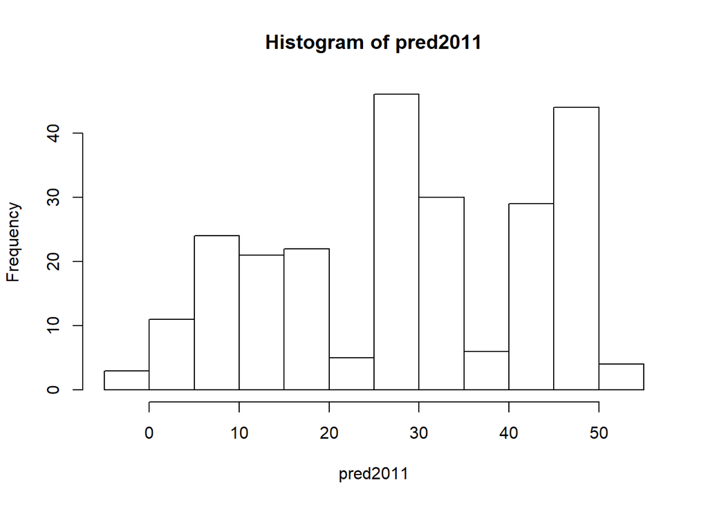

```r
pred2011 = predict(model2, cars2011a)
#print(pred2011)
hist(pred2011)
```

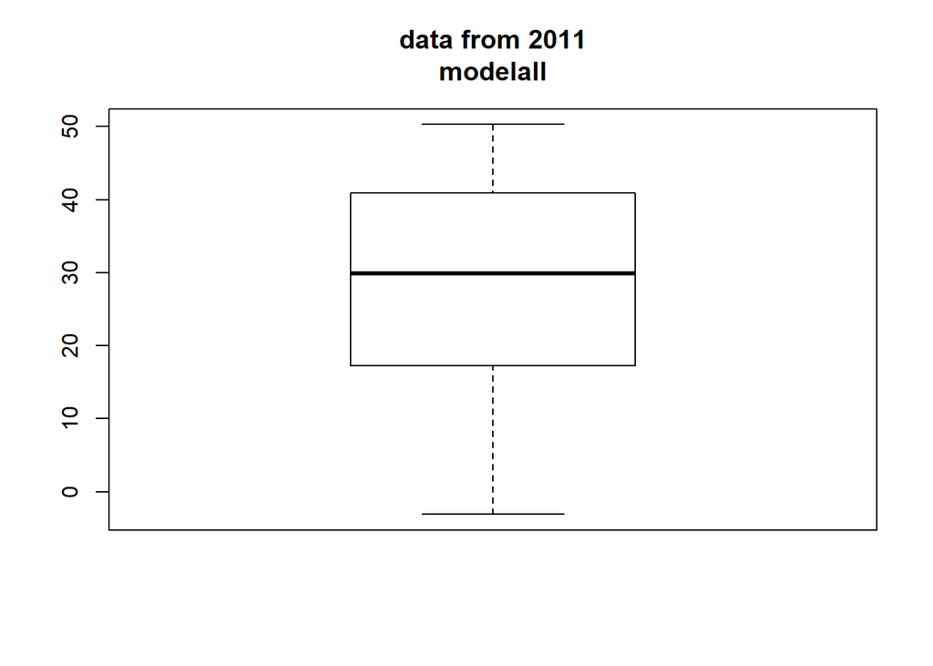

```r
boxplot(pred2011, main= 'data from 2011\nmodelall')
```

```r
t.test(cars2011a$FE, pred2011)
```

```
##
##  Welch Two Sample t-test
##
## data:  cars2011a$FE and pred2011
## t = 5.5458, df = 411.56, p-value = 5.241e-08
## alternative hypothesis: true difference in means is not equal to 0
## 95 percent confidence interval:
##  3.947720 8.282937
## sample estimates:
## mean of x mean of y
##  34.73066  28.61534
```

3. Suggest ways in which fuel efficiency could be improved in future years.

### 3 Answer

Suggested improvements for future years would be to only make front wheeled drive vehicles. also, they smaller the engine displacement they can manufacture while keeping the car able to perform will be the most beneficial improvement. Also variable valve timing does improve efficiency when it is used. Trans lockup should not be used if FE is the only factor that they are looking to improve, it may have other benefits, but it is a detriment to fuel effeciency.